# Kaggle_Survey slides

With the everchanging world one can be easily be influenced by thew modern tools being developed around the globe to make our lives better. Data scince is one such tool which is in spot light.

Today every equipment we use is collecting some data to make our lives easier but so much data is being gathered that it become difficult to make sense out of it. One of the resposibilities of a Data Scientist is to present this data in a way that everyone can understand it.

It also shows how much money various industies are investing in data science.  
The analysis of this survey majorly concludes that Data Scince is open not only for veterans but there is also room for new comers to explore teir skills in data science.

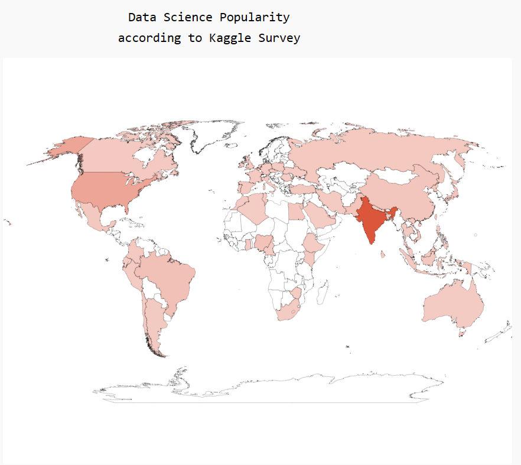

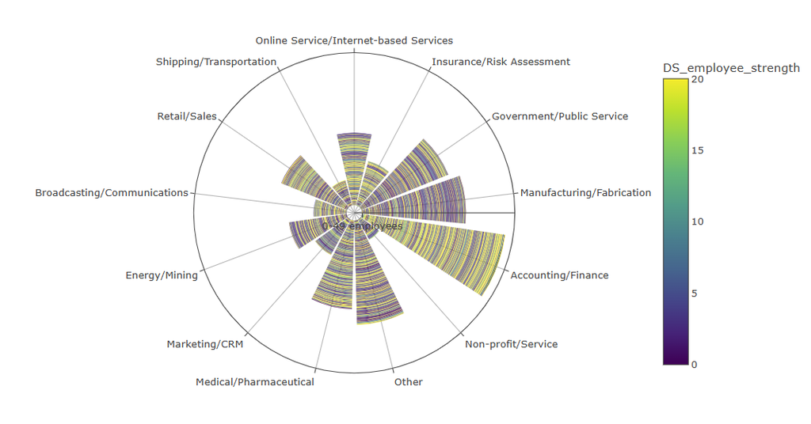

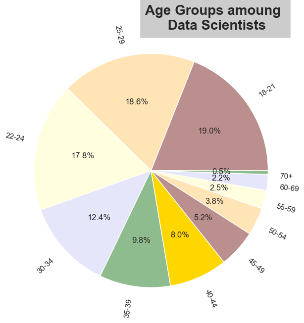

Showing Contry Distribution in Survey

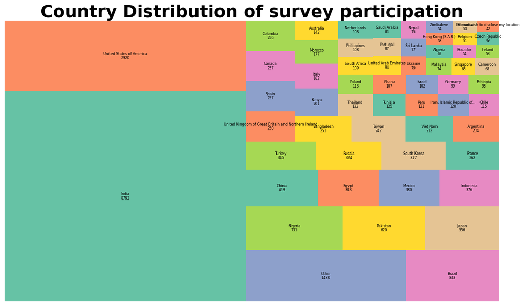

Deleting extra columns

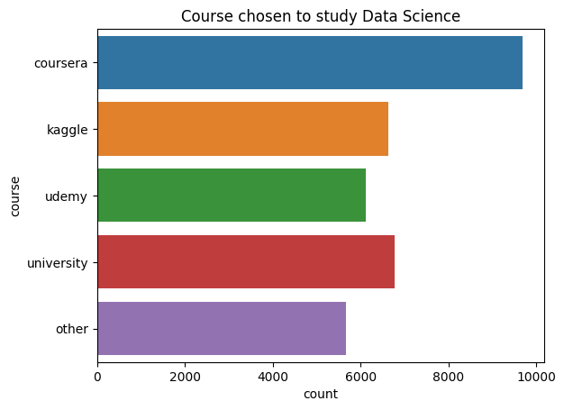

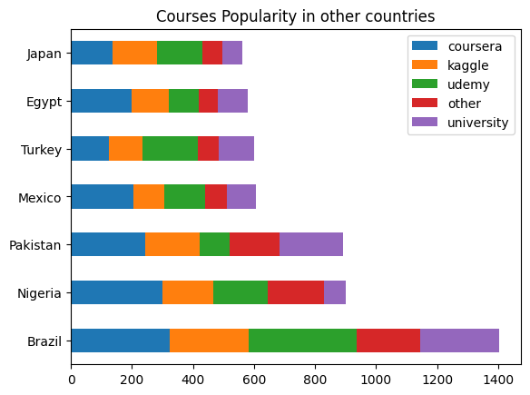

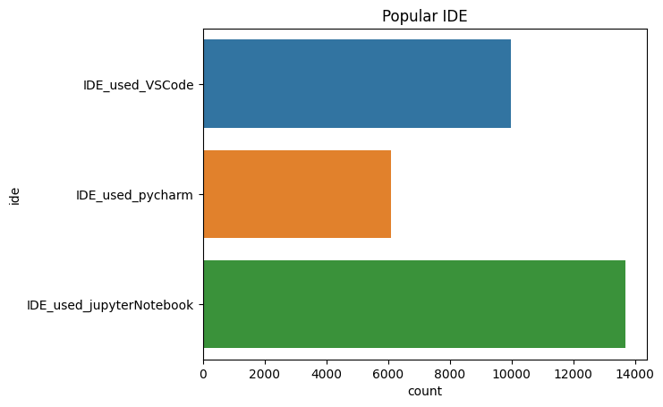

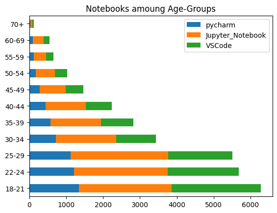

Exporting data to new dataframe

df.to_csv('kaggle_survey_2022_responses_5_v6.csv')

IMporting dataframe and country_code file

### Creating a dictionary from country code file to represent of the world map

maping dictionary of code with the Kaggle dataframe column country

Manualing adding missing countries to the dataframe

Creating a new dictionary to show country: count of Data scientist

Creating a visually appealing world map which highlights the popularity of DATA science in the world

pip install pygal_maps_world

pip install svglib

```
Eureka!!
```

[interactive chart not shown]

### Checking the yearly compensation for data_Science

Yearly Compensation of DATA Scientists

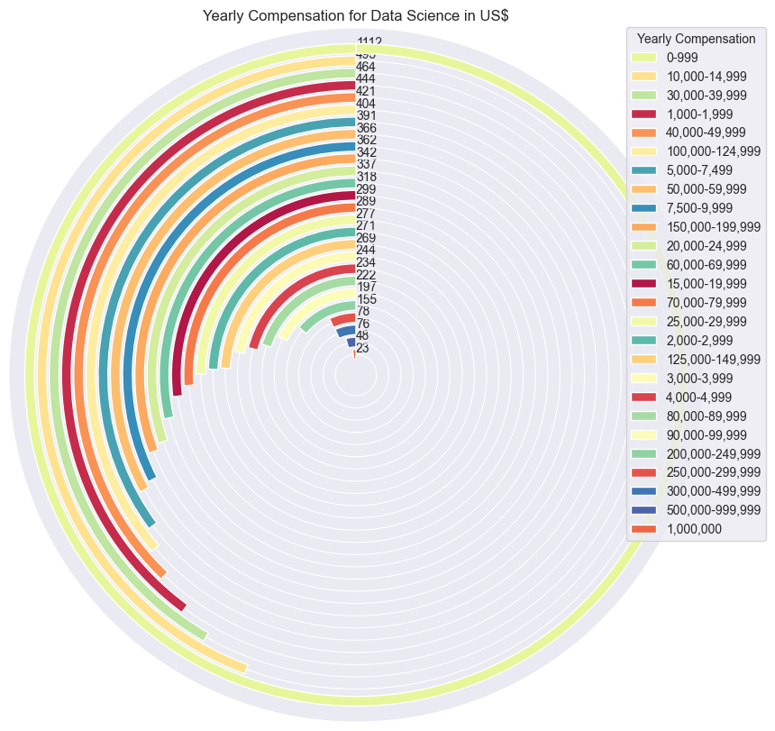

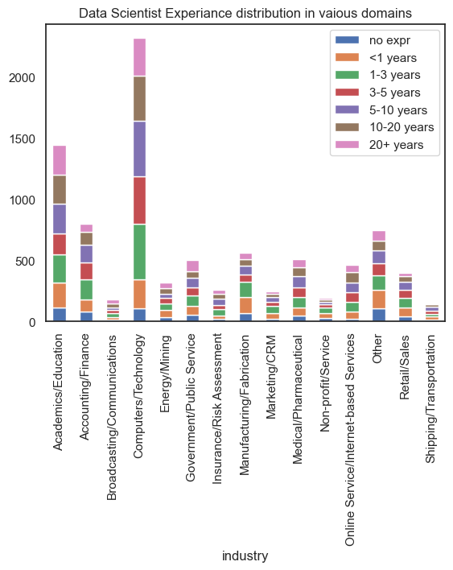

### Apart from the Computer sector Data Science importance

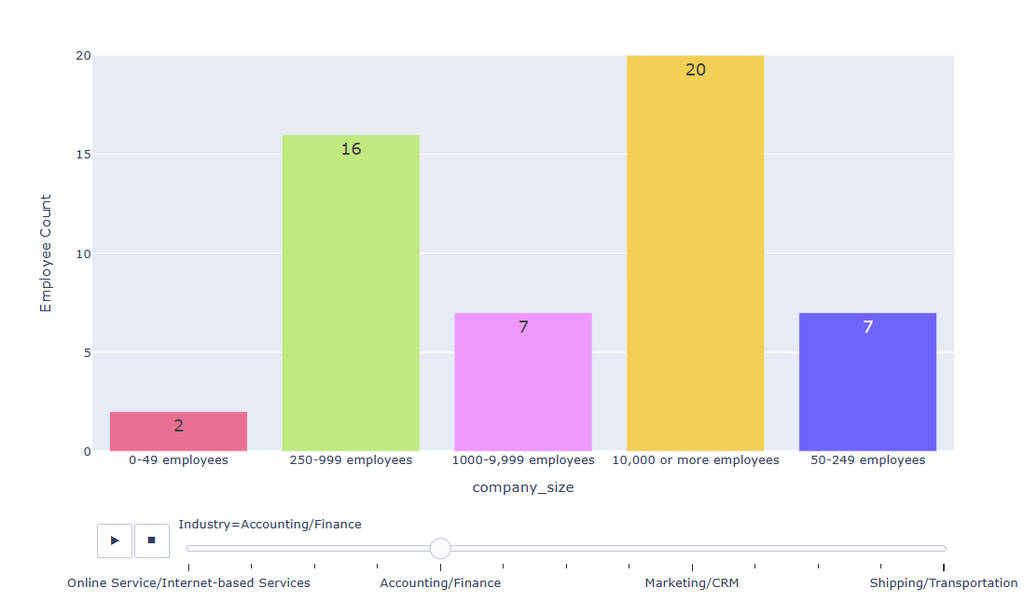

Plotting Regular Languages used by Data Scietists

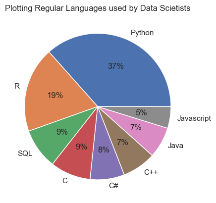

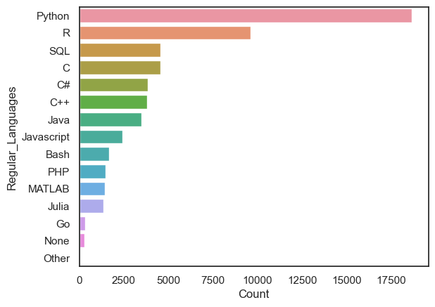

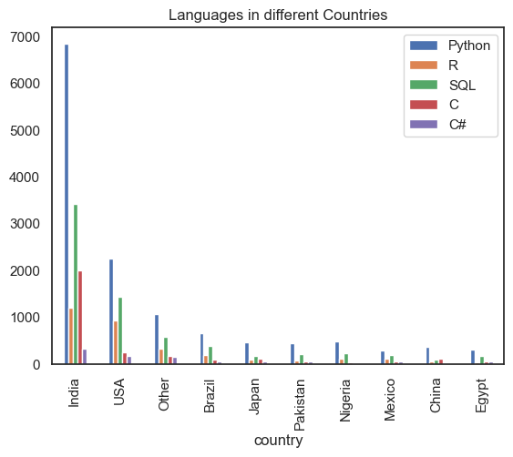

Summerizing Technical survey results

Platform Chosen to study Data Science

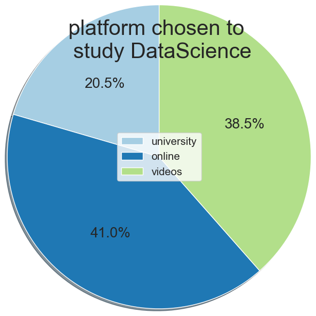

Assigning other veriables

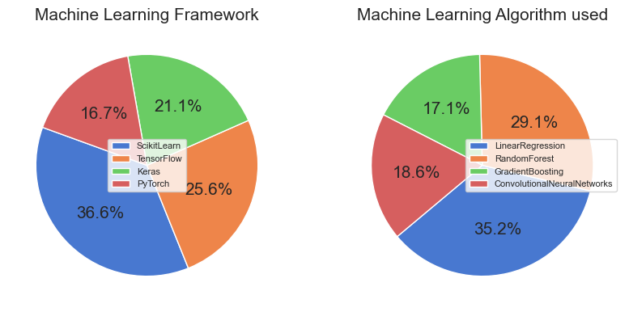